# Tutorial for the pssr R package

Angelos-Miltiadis Krypotos & Gaëtan Mertens

Here, we provide a brief tutorial for the pssr R package. The *pssr* package provides a suite of functions for preregistrating and sharing data/materials. Although it was initially designed as an easy-to-use tool for experimental psychopathologists and other researchers acoss Clinical psychology, it can also be used from any researcher running experimental studies.

Here, we first provide instructions on how to install the package. Then, we explain each tab of the software one by one. Lastly, we go through a hypothetical example. The rationale behind the design of the package can be found in our  
paper available here: [A Step-By-Step Guide on Preregistration and Effective Data Sharing for Psychopathology Research](https://osf.io/yvnfj/).

## Installation instructions

Before installing the *pssr* package, make sure that you have the most recent versions of the following software installed: [R](https://cran.r-project.org), [Rtools](https://cran.r-project.org/bin/windows/Rtools/), and [git](https://git-scm.com/%5D), pandoc. You can also choose between installing [MikTex](https://miktex.org/download) or [tinytex](https://yihui.name/tinytex/) – *tinytex* is lighter and seems to be working fine for basic documents.

After that, start a new R session and paste the following commands in the R console.

```r
if(!require(devtools)) { install.packages("devtools") }
# Install devtools (in case you need to)
devtools::install_github("AngelosPsy/pssr")
```

If everything went as planned, the software is now ready to be used. To test that, check whether the next step works. In case you have any problems during installation, please open an issue [here](https://github.com/AngelosPsy/pssr_tutorial/issues). Instructions about how to open an issue are provided [here](https://help.github.com/articles/creating-an-issue/).

## Initiating a pssr session

The main function is the pssr::shiny_app() that initiates a new [shiny](https://shiny.rstudio.com/) session. As in any other function in R, just paste:

```r
pssr::shiny_app()
```

in the R console. After doing that, a browser window will appear. The browser window will look as follows:

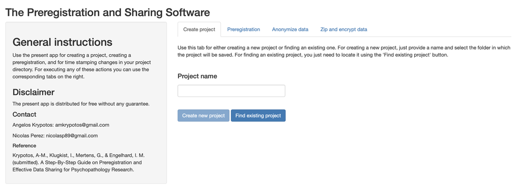

We now explain each tab of the software separately.

## Create project Tab

For creating a new project, navigate to the ‘Create project’ tab. Then, place a name in the ‘Project name’ box and click on the ‘Create new project’. To reopen an existing project the user can just click on the ‘Find existing project’ box and navigate to an existing project. In case a folder is selected that was not created by the *pssr*, the program will return a warning.

When a project folder is created, the program automatically creates a directory with the project’s name. Inside the directory the following subdirectories are created: “analyses”, “data”, “manuscript”, “material”, and “preregistration”.

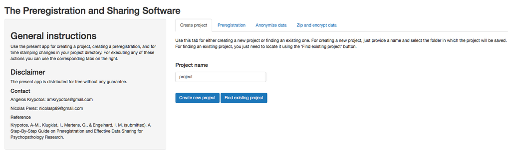

## Preregistration Tab

For creating a preregistration document, you can enter a name in the “Enter name of the preregistration”. Then, choose the template you want to use so as to form your preregistration. The *pssr* software supports 3 templates. These are the ‘pss’, the ‘aspredicted’ from the aspredicted website, and the ‘osf’ from the osf website. In case the ‘pss’ template is selected, then a new tab is presented, with each tab now having different boxes for every different piece of information that needs to be preregistrated (e.g., methods, statistical analyses). We describe what type of information should be included in each box in our paper. An example of a pre-registration can be found below.

In case the ‘aspredicted’ or the ‘osf’ template are selected, then a new window will appear. The user then can manipulate the text using the (Rmarkdown)[https://rmarkdown.rstudio.com] template. For these templates, we use the (prereg)[https://cran.r-project.org/web/packages/prereg/index.html] package authored by (Frederik Aust)[https://github.com/crsh].

### Generate a pdf of the pregistration file

Under ‘Preregistration’ press ‘Choose files’. On the pop up window, go to the ‘preregistration’ folder. Inside that folder, select the ‘.Rmd’ file with the name of the preregistration file you want to manipulate and click on ‘Select’. After that, click on the ‘Create PDF’s’. Then the pdf files of the preregistration files are now being saved in the ‘preregistration’ folder.

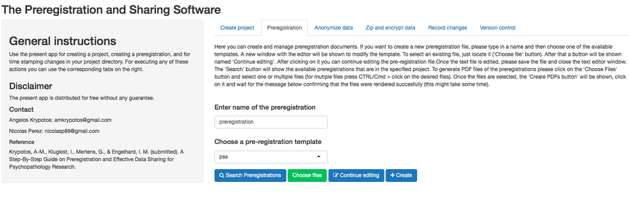

## Anonymize data

Our software can also be used to anonymize data. For that, navigate to the ‘Anonymize data’ folder. Then, choose a CSV file that can be used for anonymizing data. The software currently accepts only csv files. After that, select the columns that will be anonymized. After selecting the columns, you can select either to fill in the columns using random numbers or just encryption algorithms by clicking one of the options in the drop down menu named ‘*How to anonymize data?*’.

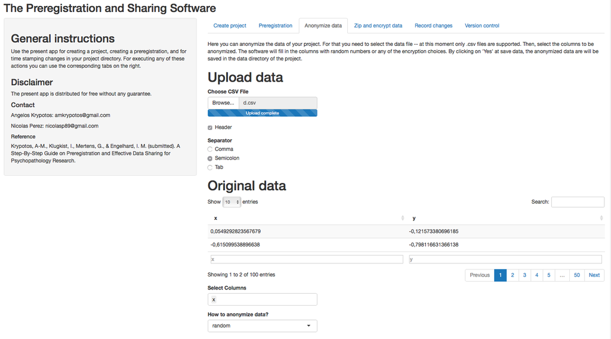

## Zip and encrypt data

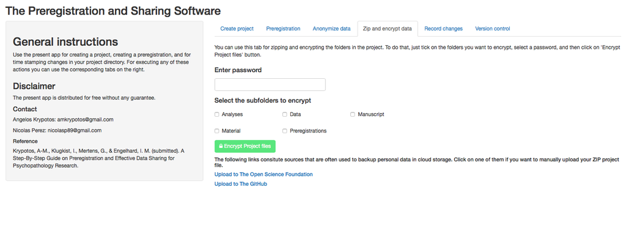

# Example of using the *pssr* software

For this example, we are going to be based on the preregistration of the study [“Modality-specific dual-task interference on aversive memories”](https://osf.io/zgw3r/) , written by Gaëtan Mertens, Vera Bouwman, Jonas Asmervik, & Iris M. Engelhard. Please note that we describe below more steps than the ones used in the preregistration. Also, we deviate from the preregistartion material in order to provide a more detailed example. In some cases, we note, using the word *note*, some parts of the preregistrations that could have been better. Our goal is to show the reader that preregistrations that seem to be complete, miss some important information that could have made them more detailed. We extend on this issue also in our main paper.

# STEP ONE: Initialise a project

# STEP TWO: Fill in the details in the ‘Create Project’ tab

Here, we first need to fill in the name of our project (i.e., Modality-specific dual-task interference on aversive memories). Then, we should click on the *Create new project* tab. On the window that appears, you can select the directory (i.e., computer folder) where you want your project folders to be stored. If anything goes as planned, the directory that the project is stored will be printed on screen (e.g., C/Desktop/ProjectName). Please note that everytime you want to open the projet, you can just click on the “Find existting project”, locate the folder that contains your project (for the example that would be the folder named “Modality-specific dual-task interference on aversive memories”) and open it. Please note that if a folder is selected that was not created by *pssr*, a warning will be returned. This will mean that also some functions of the *pssr* will not work (e.g., the zip function).

# STEP THREE: Preregistration

Now that the project has been created (see (Step two)[#step2]), we are ready to create our preregistration document. For that, first click on the *preregistration* tab. We first need to name our preregistration document. This could be something as simple as “preregistration”. Then, we need to choose one of the available preregistration templates. The pssr provides 3 different preregistration templates: the pss, aspredicted, and cos templates. The last two templates were provided by the [prereg](https://cran.r-project.org/web/packages/prereg/index.html) R package of [Frederik Aust](https://github.com/crsh). The first template was written by us and it is the template we describe in our relevant [paper](https://osf.io/yvnfj/). Here, we descibe only the pss template as for the other two, there other relevant resources (e.g., https://osf.io/zab38/wiki/home/).

In order to select the pssr template, the user can just select the template from the drop down menu named *choose a pre-registration template*. Then, click on the *Create* button. After doing that, a new tab will be created, with separate boxes for each one of the fields that need to be filled in. Here, we provide within boxes the inforation we have provided.

## Title

Modality-specific dual-task interference on aversive memories

## Author list

Gaëtan Mertens, Vera Bouwman, Jonas Asmervik, & Iris M. Engelhard

## Affiliation list

Department of Clinical Psychology, Utrecht University

## Background of the study

Study questions

This study will investigate whether the reduction of self-reported vividness and emotionality of aversive memories in dual-task paradigms can be enhanced by using modality-specific interference.

Study hypotheses

A greater reduction in vividness and emotionality in visual memories is expected after a visuospatial taxation task compared to an auditory taxation task. In addition, a greater reduction in vividness and emotionality in auditory memories is expected after an auditory taxation task compared to a visuospatial taxation task.

*Note* As also mentioned in the paper, better hypotheses would also specify the size of the effect – something that is not done here. Also, the main hypotheses do not include the operationalization of some of the key variables (e.g., vividness, emotionality). This could be problematic given that we could have taken different measures of these variables, and used only the ones that satisfied our hypotheses.

## Methods

Stimuli

Three visual stimuli (IAPS pictures 9181, 3400, and 6350) and three auditory stimuli (IADS sounds 286, 275, and 279) are randomly assigned to the three tasks.

## Questionnaires

No questionnaires are included in this study.

## Equipment

This study will be run on a standard laboratory PC. The experiment was programmed in Inquisit v4.0.

## Procedure

All participants will complete three tasks: (1) Control task: watching a white screen, (2) Visual task: detecting a target letter (e.g., p) between distractors (e.g., q) appearing alternatingly on the sides of the computer screen (Homer, Deeprose, & Andrade, 2016), (3) Auditory task: detecting a target letter (e.g., d) between distractors (e.g., e) presented by male and female voices on alternating sides of the headphone. During each of the tasks participants will have to recall their memory for either an emotional picture or sound (also on a within-subject basis).

## Protocol

Protocol - Experiment Modality specific interference

Version: June 2018

Materials:

- Computer with Inquisit experiment
- Chair
- Headphones
- 2 pencils
- Protocol experimenter
- Counterbalance scheme
- Information letter
- Informed consent (2x)
- Questionnaire prior knowledge modality specificity
- Debriefing
- Money
- Money/course credits received checklist

Preparation:

- Turn on the computer and log on -> right icon, password = fswlab
- Make sure that the sound on the computer is set correctly -> full?
- Open the experiment in Inquisit -> Labshare(L-schijf) -> Gaetan Mertens -> Experiment Modality specific interference (Jonas Asmervik) FINAL -> Experiment.iqx
- Insert the correct participant and group number based on the counterbalance scheme. Put on the red light in the cubicle when you enter the lab with the participant.

Introduction:

“Welcome to the eye-movement study with aversive images and sounds. I would like to ask you to switch off / silence your phone.  
This study consists of a computer task which will take approximately 40 minutes. I would like you to read the information letter concerning this experiment. If you then decide to participate, I would like you to ask to fill in the informed consent.” Give participant the information letter.

When participant is done reading:

“Do you have any questions? Would you like to participate?”

If yes, give two informed consents:

“Please fill in these two forms. One is for you, the other is for our administration.”

Instructions on computer task:

“You now will start with the computer task. Please sit close to the desk with your upper body barely touching. During the experiment, sounds are presented to you through these headphones. Please wear the headphones throughout the experiment.  
All instructions will appear on the screen. When you are finished, please come out and see me at the front desk.

Do you have any questions?"

Answer any questions

“You can press the spacebar when I have left the cubicle to start the experiment. Good luck.”

Leave the cubicle

End of the experiment:

When the participant is finished with the computer task, assess the prior knowledge of modality specificity questionnaire.

Provide debriefing and sign it after the participant has signed it.

Provide incentive:

“This is the end of the experiment. Thank you for participating. You will receive 8 euro’s / 1 course credit as incentive. Will you fill in this list?”

## Participant number

The sample size calculation is based on pilot data. As G-power does not allow for a repeated measures ANOVA within-within interaction, we calculated the sample size by using the dependent means t-test option. Therefore, we restructured the pilot data into two variables: congruent modality (M reduction vividness = 21.53, SD = 19.99) and incongruent modality (M reduction vividness = 14.99, SD = 14.02) and determined the effect size (dz = 0.31). Sample size calculation using a dependent *t*-test with an a of .05 and statistical power of 1 - $\beta$ = .80 indicated a required sample of 66 participants. Because of the counterbalance procedure (the sample size needs to be multipliable by 12) and feasibility, the final sample size will be 60 participants. Post hoc power calculations indicates that a power of .77 will be obtained with 60 participants, which we considered sufficient.

## Stopping rule

Data collection will continue until valid data for 60 participants is obtained.

## Confirm hypotheses

The memory vividness and emotionality scores will be analyzed separately in two repeated measures ANOVAs with task (visual, auditory, control) and stimuli (visual, auditory) as a within-subject factors and the difference scores (pre- and post-measurements) as dependent variable. To further explore the results, paired sample t-test will be performed to compare the different tasks per stimuli. The analyses will be conducted within the traditional null hypothesis testing framework (NHST) using an $\alpha$ of .05.  
Our primary hypothesis is that there will be an interaction between task and stimuli, with greater memory vividness and emotionality difference scores in the visual task using a visual stimuli and greater memory vividness and emotionality difference scores in the auditory task using auditory stimuli. In comparison, incongruent modality interferences are expected to show less reduction in memory vividness and emotionality. Furthermore, we expect overall greater reductions in memory vividness and emotionality in the experimental conditions compared to the control condition.

## Disconfirm hypotheses

Any evidence opposite to the previous predictions would be provide first evidence of disconformination of our hypotheses.

## Other

Not applicable.

## References

Baddeley, A. D. (1983). Working Memory. Philosophical Transactions of the Royal Society of London. *Series B, Biological Sciences*, *302*, 311-324. https://doi.org/10.1098/rstb.1983.0057

Homer, S. R., Deeprose, C., & Andrade, J. (2016). Negative mental imagery in public speaking anxiety: Forming cognitive resistance by taxing visuospatial working memory. *Journal of Behavior Therapy and Experimental Psychiatry*, *50*, 77-82. https://doi.org/10.1016/j.jbtep.2015.05.004,

# STEP FOUR: Anonymize data

The anonymize data tab can be used for anonymizing the data easily. Please note, though, that all functions are provided as an easy step ensuring anonymization of the data. However, all users should check whether indeed the data are fully anonymized before releasing them in public. For the sake of the example, we will open the “exampleDataSet.csv” file. These data are already anonymized but we have added an extra column with random numbers. The data set looks as follows:

```
##    ID Auditory  Control     Vis1     Vis2     Vis3 Grand.Total Age
## 1   1 500.9775 348.7957 570.1647 614.3012 527.0000    508.7945  18
## 2   2 421.9895 418.1443 558.1918 557.9552 566.3333    491.1594  18
## 3   3 444.0851 419.3152 485.2432 482.8611 521.7200    466.2955  22
## 4   5 393.4330 346.9500 531.5208 566.7143 478.6795    437.0137  20
## 5   7 365.0928 315.7864 578.3571 455.0115 492.4725    434.8983  19
## 6   8 564.9041 382.7957 508.5493 522.3538 499.0896    488.7182  23
## 7   9 495.4568 358.5684 634.8194 634.6207 636.6000    539.1867  19
## 8  10 368.1020 374.3113 528.4412 522.1220 541.2000    433.7961  19
## 9  12 596.4444 510.3267 649.7143 578.2292 630.8333    579.9603  19
## 10 14 485.5238 349.2404 536.4127 502.9747 483.8485    461.0303  19
## 11 15 529.7447 377.1613 465.9091 655.6667 477.0294    483.7621  21
## 12 16 490.8571 492.7681 604.1765 643.5926 604.9032    557.2000  20
## 13 17 494.3810 392.1343 554.0488 473.1739 570.5588    484.2851  21
## 14 18 453.4533 363.6795 579.2381 535.0938 511.8980    480.8419  18
## 15 19 579.5455 361.6324 571.3750 600.2000 532.0462    512.3594  22
## 16 21 407.8861 354.6117 393.1316 425.8378 568.2000    419.6275  21
## 17 23 446.6429 349.3966 413.4426 354.0588 462.8462    406.1927  20
## 18 24 483.8219 400.9070 519.3611 407.5541 520.2899    471.3323  20
```

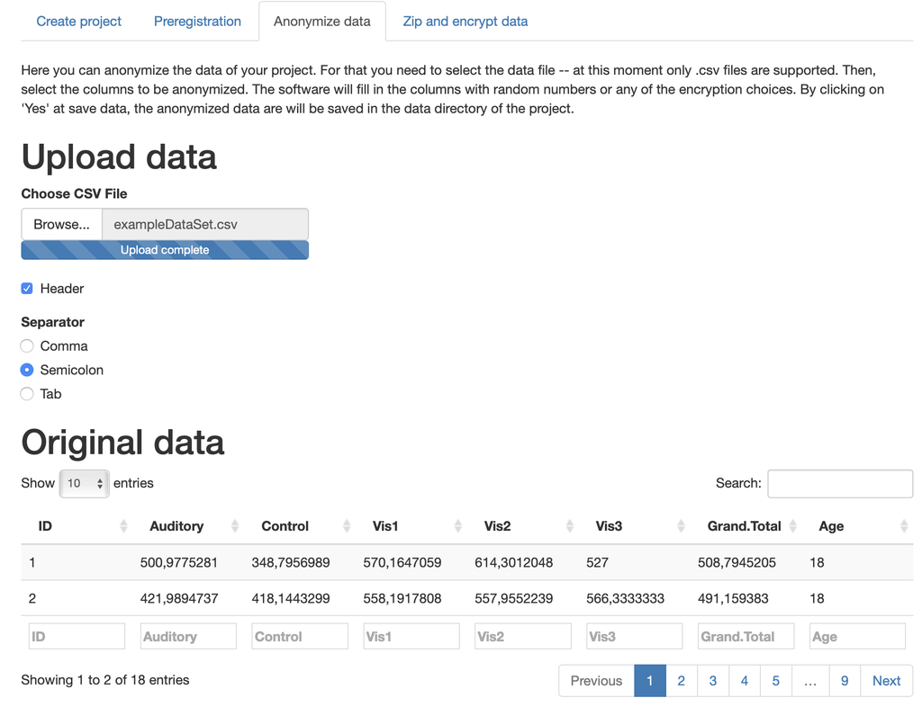

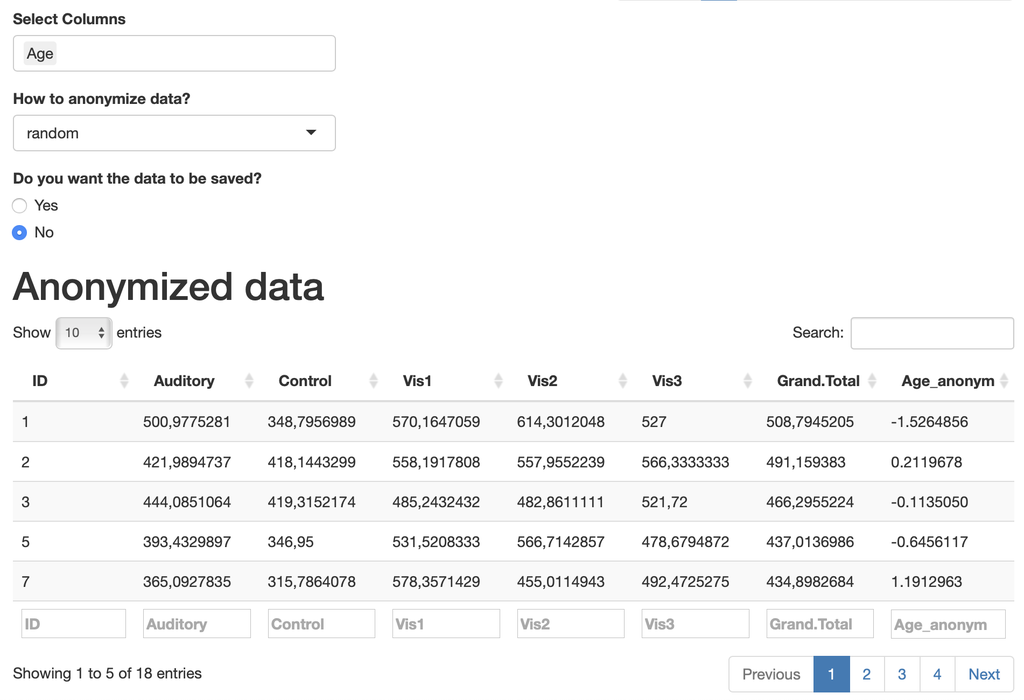

# STEP FIVE: Zip and encypt data

Here, we just type in a password in the *Enter password* field (here the word ‘password’). Then, we select the subfolders that we want to be encrypted (here the ‘Analyses’ and ‘Material’ subfolders). Lastly, we click on the *Encrypt Project files* button. If anything went as predicted, the directory where the zip file was located should be shown on screen (here hidden for privacy issues).

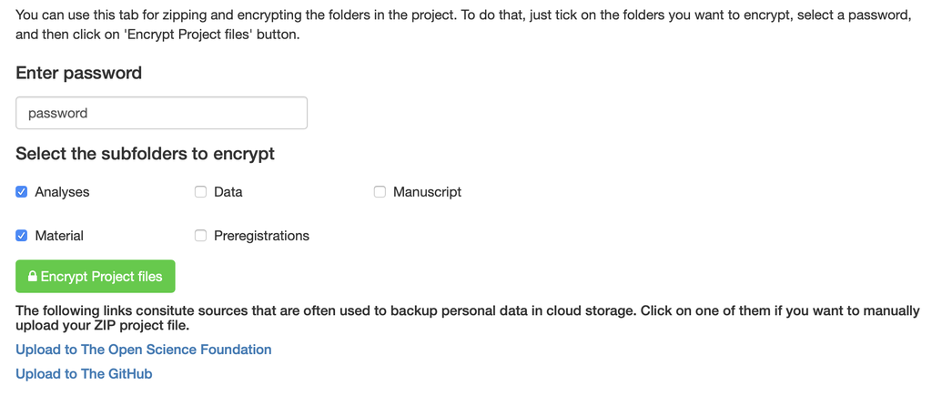

# STEP SIX: Record changes

Although this is descibed as the sixth step, the “*Record changes*” tab should be visited often during the whole project and not just in the end. Specifically, it is best to record as many changes as possible as this will provide a better view of the changes made throughout the whole project. In our example, we have just filled in a username and an email. Then, and every time we want to timestamp the changes made in the project, we just provide a brief description of the changes we have made (e.g., anonymized data) and then click on the ‘timestamp changes’. Whenever we want to see if any changes have been made in the files, we can click on the ‘track changes’ button.

As explained in our main paper, no new copies of the files are made. However, sometimes maybe the user wants to revert to an older version of the files. The *version control* tab was designed for exactly this. For that, just click on the folders you want to revert to and then go to the commit you want to revert to using the *Go to Commit* button. Please note that there should be at least one commit in order for this feature of the software to work. In case of no commits, the tab will return an error.